# slide_deck slides

##### Loan performance in association with borrowers and lenders.

##### Investigation overview

In this investigation, we look at borrowers and how various variables affect loan performance.

##### Dataset overview

The prosper loan dataset is a financial dataset. Prosper is an American company that offers loans at low interest rates to the borrowers. The dataset is comprised of 81 variables and contains 113937 entries. We looked at Term, Borrower rate, Stated monthly income, loan original amount, Prosper rating, Employment Status and Estimated returns

##### Distribution of Employment Status

The employment status feature has 8 unique values with Employed being the top followed by full-time and self-employed.

[figure not shown]

##### Distribution of prosper rating

The ProsperRating (Alpha) merged with CreditGrade produces ProsperRatingMerged. The most frequent rating is C. The distribution is skewed to the right.

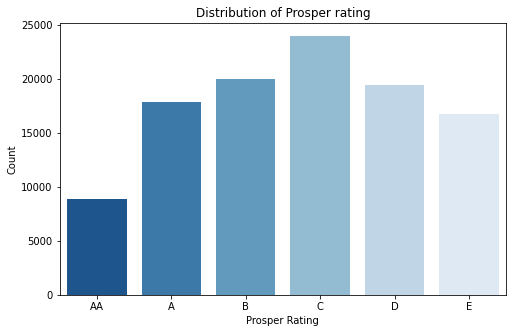

##### Employment status and ProsperRating

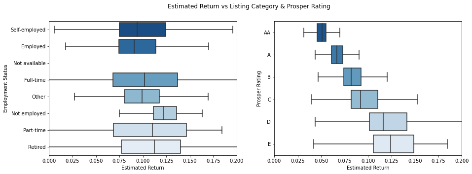

##### Employment Status and Borrower Rate

The prosper rating increases with higher borrower rate.

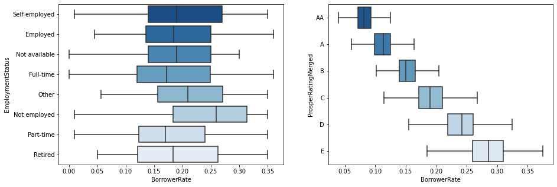